# Robust Standard Errors

Dr. Lucy D’Agostino McGowan

## What are Robust Standard Errors?

**The Problem:** Standard OLS assumes homoskedasticity (constant variance)

$$\text{Var}(\varepsilon_i | X) = \sigma^2 \text{ for all } i$$

**Reality:** Often $\text{Var}(\varepsilon_i | X) = \sigma_i^2$ varies across observations

**Solution:** **Heteroskedasticity-robust standard errors** (also called “sandwich” or “Huber-White” standard errors) remain valid even when variances differ

# The Problem: Heteroskedasticity

## What is Heteroskedasticity?

**Heteroskedasticity:** The variance of errors depends on $X$
$$\text{Var}(\varepsilon_i | X_i) = \sigma_i^2 \neq \sigma^2$$

## Visualizing Heteroskedasticity

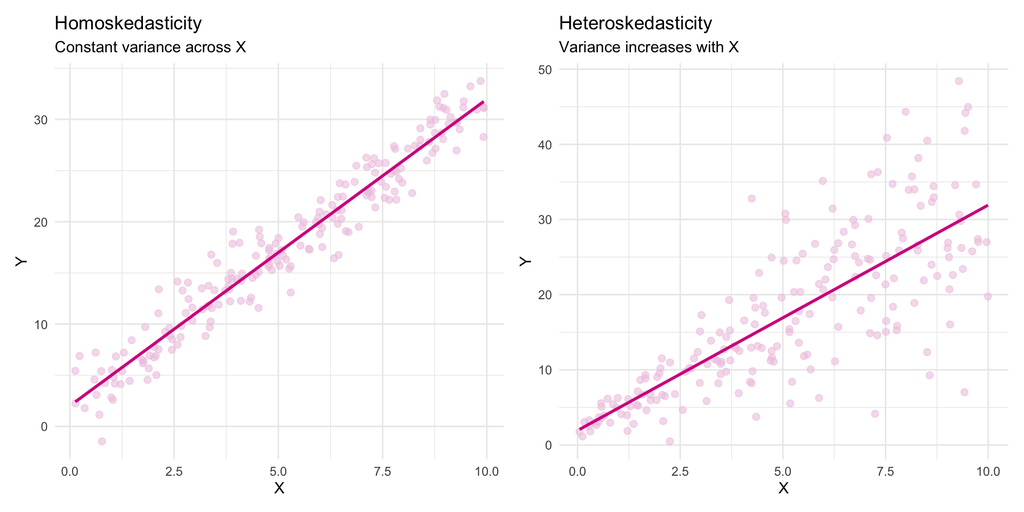

**Right panel:** The spread increases as X increases

## Why Does Heteroskedasticity Matter?

**Good news:** OLS estimator $\hat{\beta}$ is still **unbiased** and **consistent**

**Bad news:** The usual standard error formula is **wrong**!

Standard OLS variance formula assumes:
$$\text{Var}(\hat{\beta}) = \sigma^2(X^TX)^{-1}$$

**Problem:** This formula assumes constant $\sigma^2$, but we have varying $\sigma_i^2$

## Consequences of Using Wrong SE

Using standard SEs with heteroskedasticity leads to:

1. **Invalid hypothesis tests** (wrong p-values)
2. **Invalid confidence intervals** (wrong coverage)
3. **Misleading inference** (false positives or negatives)

**The coefficient is fine, but we can’t trust our uncertainty estimates!**

# The Solution: Robust Standard Errors

## The Correct Variance Formula

With heteroskedasticity, the true variance of $\hat{\beta}$ is:
$$\text{Var}(\hat{\beta}) = (X^TX)^{-1} \left(\sum_{i=1}^n X_i X_i^T \sigma_i^2\right) (X^TX)^{-1}$$

**Problem:** We don’t know the true $\sigma_i^2$

**Solution:** Estimate each $\sigma_i^2$ with the squared residual $\hat{\varepsilon}_i^2$

## The Sandwich Estimator

**Robust variance estimator (HC0):**
$$\widehat{\text{Var}}(\hat{\beta}) = (X^TX)^{-1} \left(\sum_{i=1}^n X_i X_i^T \hat{\varepsilon}_i^2\right) (X^TX)^{-1}$$

## The Sandwich Estimator

Called the **“sandwich”** because of its structure:
$$\underbrace{(X^TX)^{-1}}_{\text{bread}} \underbrace{\left(\sum X_i X_i^T \hat{\varepsilon}_i^2\right)}_{\text{meat}} \underbrace{(X^TX)^{-1}}_{\text{bread}}$$

## Why “Robust”?

This estimator is **robust** to heteroskedasticity:

- **If errors are homoskedastic:** Robust SE ≈ Standard SE (asymptotically)
- **If errors are heteroskedastic:** Robust SE is correct, Standard SE is wrong

**Big picture:** Robust SEs work whether or not you have heteroskedasticity

## Variants of Robust Standard Errors

Several versions exist, with different finite-sample adjustments:

**HC0 (Original):** $\widehat{\text{Var}}(\hat{\beta}) = (X^TX)^{-1} \sum X_i X_i^T \hat{\varepsilon}_i^2 (X^TX)^{-1}$

**HC1:** Multiply by $\frac{n}{n-k}$ for degrees of freedom

**HC2:** Weight by $(1-h_{ii})^{-1}$ where $h_{ii}$ is leverage

**HC3:** Weight by $(1-h_{ii})^{-2}$ (more conservative)

**In practice:** Use HC1 or HC3; differences usually small with large $n$

## Computing Robust Standard Errors in R

```r
# Generate heteroskedastic data
set.seed(1)
n <- 100
x <- runif(n, 0, 10)
y <- 2 + 3*x + rnorm(n, sd = 0.5 + 0.4*x)

# Fit OLS
model <- lm(y ~ x)

# Standard SEs
summary(model)$coefficients
```

```
            Estimate Std. Error   t value    Pr(>|t|)
(Intercept) 1.702826 0.56627540  3.007063 3.35136e-03
x           3.065759 0.09725122 31.524122 4.23507e-53
```

```r
# Robust SEs (need sandwich package)
library(sandwich)
library(lmtest)

coeftest(model, vcov = vcovHC(model, type = "HC1"))
```

```
t test of coefficients:

            Estimate Std. Error t value  Pr(>|t|)
(Intercept)  1.70283    0.39848  4.2733 4.469e-05 ***
x            3.06576    0.10096 30.3647 < 2.2e-16 ***
---
Signif. codes:  0 '***' 0.001 '**' 0.01 '*' 0.05 '.' 0.1 ' ' 1
```

## Comparing Standard vs Robust SEs

```r
# Create comparison
standard_se <- summary(model)$coefficients[2, 2]
robust_se <- sqrt(vcovHC(model, type = "HC1")[2, 2])

data.frame(
  Type = c("Standard", "Robust"),
  SE = c(standard_se, robust_se),
  Ratio = c(1, robust_se/standard_se)
)
```

```
      Type         SE    Ratio
1 Standard 0.09725122 1.000000
2   Robust 0.10096455 1.038183
```

**In this example:** Robust SE is larger (standard SE underestimates uncertainty)

# Alternative: Weighted Least Squares (WLS)

## What is WLS?

**Idea:** If we know the variance structure, we can use it to get more efficient estimates

Suppose we know $\text{Var}(\varepsilon_i | X_i) = \sigma^2 w_i$ for known weights $w_i$

**WLS:** Transform the model by $1/\sqrt{w_i}$:
$$\frac{y_i}{\sqrt{w_i}} = \frac{X_i}{\sqrt{w_i}}\beta + \frac{\varepsilon_i}{\sqrt{w_i}}$$

**Result:** Transformed errors have constant variance!

## WLS Estimator

**WLS minimizes weighted sum of squared residuals:**
$$\hat{\beta}_{WLS} = \arg\min_\beta \sum_{i=1}^n \frac{1}{w_i}(y_i - X_i\beta)^2$$

**Solution:**
$$\hat{\beta}_{WLS} = (X^TW^{-1}X)^{-1}X^TW^{-1}y$$
where $W = \text{diag}(w_1, \ldots, w_n)$

## Properties of WLS

**When weights are correct ($w_i = \sigma_i^2/\sigma^2$):**

1. $\hat{\beta}_{WLS}$ is **unbiased**
2. $\hat{\beta}_{WLS}$ is **BLUE** (Best Linear Unbiased Estimator)
3. $\hat{\beta}_{WLS}$ is more **efficient** than OLS
4. Standard SEs are **valid** (no need for robust SEs)

## WLS Example

```r
# True weights (in practice, we'd need to estimate these)
true_weights <- (0.5 + 0.4*x)^2

# Fit WLS
model_wls <- lm(y ~ x, weights = 1/true_weights)

# Compare coefficients
data.frame(
  Method = c("OLS", "WLS"),
  Coefficient = c(coef(model)[2], coef(model_wls)[2]),
  SE = c(summary(model)$coefficients[2, 2],
         summary(model_wls)$coefficients[2, 2])
)
```

```
  Method Coefficient         SE
1    OLS    3.065759 0.09725122
2    WLS    3.045419 0.07054892
```

**WLS has smaller standard error** (more efficient)

# Comparing WLS and Robust SEs

## Approach 1: WLS with Correct Weights

**Setup:** Use WLS with correct weights $w_i = \sigma_i^2/\sigma^2$

**Advantages:**

- Most efficient estimator (smallest variance among unbiased estimators).
- Standard inference procedures are valid.
- No need for robust SEs

## Approach 1: WLS with Correct Weights

**Setup:** Use WLS with correct weights $w_i = \sigma_i^2/\sigma^2$

**Requirements:**

- Must know the correct weights
- Weights must be correctly specified

## Approach 2: OLS with Robust SEs

**Setup:** Use OLS and compute robust standard errors

**Advantages:**

- Don’t need to know variance structure
- More flexible (works with any heteroskedasticity pattern).
- Robust to weight misspecification

## Approach 2: OLS with Robust SEs

**Setup:** Use OLS and compute robust standard errors

**Disadvantage:**

- Less efficient than WLS (larger variance)

## Efficiency Comparison

**Which estimator has smaller variance?**

**WLS with correct weights** has smaller variance than OLS

## Simulation: Efficiency Comparison

```r
# Simulation to compare variances
set.seed(1)
n_sim <- 1000
n <- 100

beta_ols <- numeric(n_sim)
beta_wls <- numeric(n_sim)

for(i in 1:n_sim) {
  x <- runif(n, 0, 10)
  w <- (0.5 + 0.4*x)^2
  y <- 2 + 3*x + rnorm(n, sd = sqrt(w))

  beta_ols[i] <- coef(lm(y ~ x))[2]
  beta_wls[i] <- coef(lm(y ~ x, weights = 1/w))[2]
}

# Compare variances
data.frame(
  Method = c("OLS", "WLS"),
  Mean = c(mean(beta_ols), mean(beta_wls)),
  Variance = c(var(beta_ols), var(beta_wls)),
  Efficiency = c(1, var(beta_ols)/var(beta_wls))
)
```

```
  Method     Mean    Variance Efficiency
1    OLS 3.003783 0.011435733    1.00000
2    WLS 3.002931 0.005519922    2.07172
```

## Visualizing the Efficiency Gain

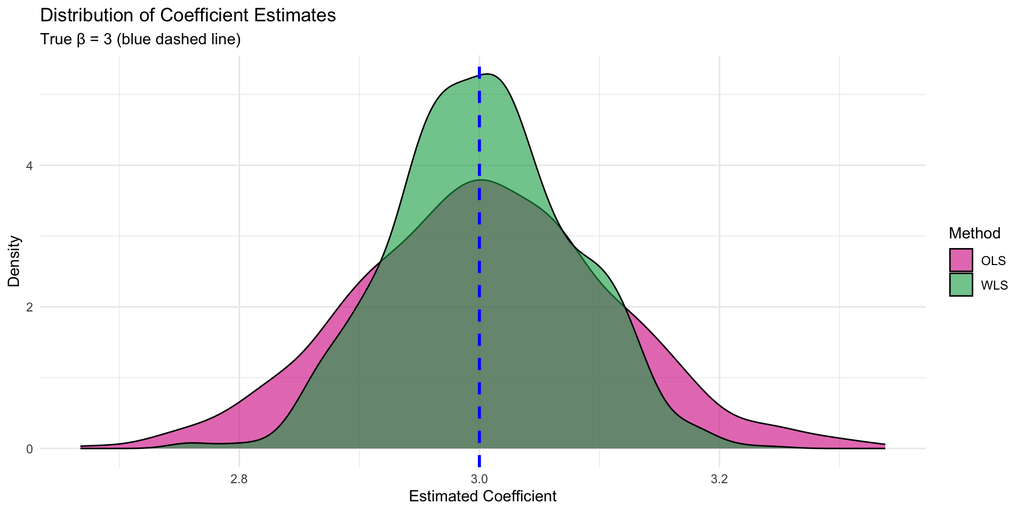

**WLS distribution is tighter** (has smaller variance)

# When is Inference Valid?

## Validity of WLS Inference

**WLS inference is valid when:**

1. **Weights are correctly specified:** $w_i = \sigma_i^2/\sigma^2$ exactly
2. **Other assumptions hold:** Linearity, independence, etc.

**Problem:** If weights are wrong, WLS inference is **invalid**

## Validity of WLS Inference

**Example:** Using $w_i = x_i$ when true variance is $\sigma_i^2 = \exp(x_i)$

- WLS estimator is still consistent but not efficient
- Standard errors are wrong
- Hypothesis tests maybe wrong

## When Weights Are Wrong

```r
# True variance structure: exponential in x
set.seed(1)
x <- runif(100, 0, 2)
true_var <- exp(x)
y <- 2 + 3*x + rnorm(100, sd = sqrt(true_var))

# Wrong weights: linear in x
wrong_weights <- x

# Fit WLS with wrong weights
model_wrong_wls <- lm(y ~ x, weights = 1/wrong_weights)

# Standard SEs are wrong!
summary(model_wrong_wls)$coefficients
```

```
            Estimate Std. Error   t value     Pr(>|t|)
(Intercept) 1.609030  0.1725209  9.326583 3.504868e-15
x           3.383816  0.2432085 13.913230 6.153096e-25
```

**These standard errors are not reliable** because weights are misspecified

## Validity of Robust SE Inference

**Robust SE inference is valid when:**

1. **Large sample size:** Robust SEs are asymptotically valid
2. **Correct model specification:** Need correct $E[Y|X]$
3. **Independence:** Observations are independent
4. **No severe leverage points:** Extreme $X$ values can cause problems

**Key advantage:** Don’t need to know variance structure!

## Asymptotic Validity

**Important caveat:** Robust SEs are **asymptotically** valid

- Need “large enough” sample size
- Can underestimate uncertainty in small samples
- Various corrections (HC2, HC3) help with small samples

# Why Prefer Robust SEs Despite Lower Efficiency?

## Reason 1: Unknown Variance Structure

**In practice, we rarely know the true weights!**

**Problem with WLS:**

- Need to model $\sigma_i^2$ as function of $X$
- If model is wrong, inference is invalid
- Hard to know if model is correct

## Reason 1: Unknown Variance Structure

**In practice, we rarely know the true weights!**

**Robust SEs:**

- No need to model variance structure
- Valid for any heteroskedasticity pattern

## Example: Modeling the Variance

Suppose we think variance depends on $x$, so we try:
$$\sigma_i^2 = \exp(\alpha_0 + \alpha_1 x_i)$$

**Steps to implement WLS:**

1. Fit OLS and get residuals $\hat{\varepsilon}_i$
2. Regress $\log(\hat{\varepsilon}_i^2)$ on $x$ to estimate $\alpha_0, \alpha_1$
3. Compute weights $\hat{w}_i = \exp(\hat{\alpha}_0 + \hat{\alpha}_1 x_i)$
4. Fit WLS using these weights

## Reason 2: Robustness to Misspecification

**Robust SEs protect against model misspecification**

**WLS with wrong weights:**

- Estimator still consistent
- But SEs are wrong
- Tests have wrong size.
- CIs have wrong coverage

## Reason 2: Robustness to Misspecification

**Robust SEs protect against model misspecification**

**OLS with robust SEs:**

- If variance model is wrong, no problem!
- Inference still valid (asymptotically)

## Simulation: Misspecified Weights

```r
# Simulation: coverage of confidence intervals
set.seed(1)
n_sim <- 1000
n <- 100
coverage_wls_wrong <- 0
coverage_robust <- 0

for(i in 1:n_sim) {
  x <- runif(n, 0, 2)
  true_var <- exp(x)  # True variance
  y <- 2 + 3*x + rnorm(n, sd = sqrt(true_var))

  # WLS with wrong weights (linear instead of exponential)
  wrong_weights <- x
  model_wls <- lm(y ~ x, weights = 1/wrong_weights)
  ci_wls <- confint(model_wls)[2,]
  coverage_wls_wrong <- coverage_wls_wrong + (ci_wls[1] <= 3 & ci_wls[2] >= 3)

  # OLS with robust SEs
  model_ols <- lm(y ~ x)
  se_robust <- sqrt(vcovHC(model_ols, type = "HC1")[2,2])
  ci_robust <- coef(model_ols)[2] + c(-1.96, 1.96) * se_robust
  coverage_robust <- coverage_robust + (ci_robust[1] <= 3 & ci_robust[2] >= 3)
}

data.frame(
  Method = c("WLS (wrong weights)", "OLS + Robust SE"),
  Coverage = c(coverage_wls_wrong/n_sim, coverage_robust/n_sim),
  Target = c(0.95, 0.95)
)
```

```
                   Method Coverage Target
2.5 % WLS (wrong weights)    0.715   0.95
          OLS + Robust SE    0.929   0.95
```

**WLS with wrong weights:** Coverage far from 95%! **Robust SEs:** Coverage close to nominal level

## Reason 3: Simplicity and Transparency

**Robust SEs are simpler:**

- No need to specify variance model
- Fewer modeling choices

**WLS requires:**

- Choosing functional form for variance
- Estimating variance model
- Potential for specification error

## Reason 4: Avoid Optimization Over SE

**Researcher degrees of freedom:**

With WLS, researchers might:

- Try different variance models.
- Pick the one that gives desired results.
- “Optimize” standard errors

**Robust SEs prevent this:**

- One standard approach
- Less flexibility for p-hacking
- More credible inference

## When Might You Prefer WLS?

**Despite the advantages of robust SEs, use WLS when:**

1. **You truly know the weights** (e.g., aggregated data with known group sizes)
2. **Efficiency is critical** (small sample, need every bit of precision)
3. **Variance structure is simple and obvious** (e.g., repeated measurements)

**Example:** Survey data with known sampling weights